# Applied Multivariate: Latent class analysis

```r
library(poLCA) # poLCA: Polytomous Variable Latent Class Analysis
#library(lavaan) # Latent Variable Analysis
#library(lcca) # Latent Class Causal Analysis
library(BayesLCA) #Bayesian Latent Class Analysis
library(gridExtra)
library(tidyverse)
```

# Latent variable analysis

## Latent class analysis

- Latent class analysis is another technique that is used to describe the latent groups in multivariate data
- Used on polytomous data (so good for analysis of survey data)
- Latent Class Analysis (LCA) is a statistical method for identifying unmeasured class membership among subjects using categorical and/or continuous observed variables.
- LCA can be used in many disciplines such as Health Sciences, Psychology, Education, and the Social Sciences.
- Similar to partition clustering and factor analysis, we define the number of groups *a priori*
  - models with successively larger numbers of classes are fitted, and the model that has the fewest classes while still accounting for associations among the observed indicator variables is chosen
  - Unlike FA, which groups along a number of axes, LCA groups people into latent classes.
- It is assumed that individuals can only be in one class
- Each latent class is characterized by different probabilities of having each of the characteristics related to the condition of interest.
- The latent class model seeks to stratify the cross-classification table of observed (or, “manifest”) variables by an unobserved (“latent”) unordered categorical variable that eliminates all confounding between the manifest variables.
- “latent class regression” (LCR) - the probability of latent class membership is predicted by one or more covariates

### Load the data

We will use the data set `election`. The data consisted of two sets of six questions with four responses each, asking respondents’ opinions of how well various traits describe presidential candidates Al Gore and George W. Bush. Also potential covariates vote choice, age, education, gender, and party ID.

```r
data(election)
head(election)
```

|  | MORALG | CARESG | KNOWG | LEADG | DISHONG | INTELG | MORALB | CARESB | KNOWB | LEADB | DISHONB | INTELB | VOTE3 | AGE | EDUC | GENDER | PARTY |
| --- | --- | --- | --- | --- | --- | --- | --- | --- | --- | --- | --- | --- | --- | --- | --- | --- | --- |
| 1 | 3 Not too well | 1 Extremely well | 2 Quite well | 2 Quite well | 3 Not too well | 2 Quite well | 1 Extremely well | 1 Extremely well | 2 Quite well | 2 Quite well | 4 Not well at all | 2 Quite well | 2 | 49 | 5 | 1 | 5 |
| 2 | 4 Not well at all | 3 Not too well | 4 Not well at all | 3 Not too well | 2 Quite well | 2 Quite well | NA | NA | 2 Quite well | 3 Not too well | NA | 1 Extremely well | NA | 35 | 4 | 2 | 3 |
| 3 | 1 Extremely well | 2 Quite well | 2 Quite well | 1 Extremely well | 3 Not too well | 2 Quite well | 2 Quite well | 2 Quite well | 2 Quite well | 3 Not too well | 3 Not too well | 2 Quite well | 1 | 57 | 3 | 2 | 1 |
| 4 | 2 Quite well | 2 Quite well | 2 Quite well | 2 Quite well | 2 Quite well | 2 Quite well | 2 Quite well | 3 Not too well | 2 Quite well | 2 Quite well | 3 Not too well | 1 Extremely well | 1 | 63 | 4 | 1 | 3 |
| 5 | 2 Quite well | 4 Not well at all | 2 Quite well | 3 Not too well | 2 Quite well | 2 Quite well | 1 Extremely well | 1 Extremely well | 2 Quite well | 2 Quite well | 3 Not too well | 2 Quite well | 2 | 40 | 5 | 2 | 7 |
| 6 | 2 Quite well | 3 Not too well | 3 Not too well | 2 Quite well | 2 Quite well | 2 Quite well | 2 Quite well | NA | 3 Not too well | 2 Quite well | 2 Quite well | 2 Quite well | 1 | 77 | 2 | 1 | 1 |

Lets take a quick look at the data.

Challenge 1. Create a data frame of the counts of people that rated each president among Extremely Well:Not Well at all and NAs for each characteristic 2. Create a histogram that displays those counts for each rating for each characteristic for each president

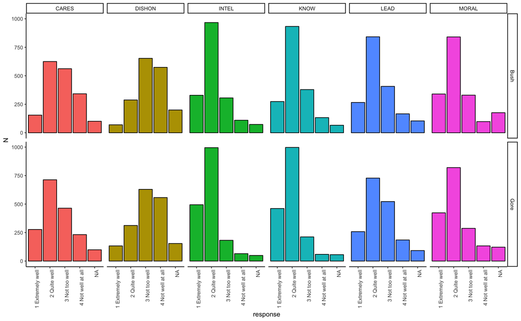

```r
election %>%
  select(MORALG:INTELG) %>%
  gather(type, response, MORALG:INTELG) %>%
  mutate(president = "Gore") -> gore_data
election %>%
  select(MORALB:INTELB) %>%
  gather(type, response, MORALB:INTELB) %>%
  mutate(president = "Bush") %>%
  rbind(gore_data) %>%
  mutate(type = gsub("G", "",type),
         type = gsub("B", "",type)) %>%
  group_by(president, type,response) %>%
  summarise(N = n()) %>%
  ggplot() +
  geom_col(aes(x = response, y = N, fill = type), color = "black") +
  facet_grid(president~type) +
  theme_classic() +
  theme(axis.text.x = element_text(angle = 90, hjust = 1),
        legend.position = "none")
```

If the number of groups fits the data well, the estimated conditional membership probabilities should be close to 1 or 0; individuals should be assigned to one of the groups with high probability

### Specifying and using the model

```r
# basic latent class specification
f.1 <- cbind(MORALG, CARESG, KNOWG, LEADG, DISHONG, INTELG, MORALB, CARESB, KNOWB, LEADB, DISHONB, INTELB) ~ 1
nes.basic <- poLCA(f.1, election, nclass = 3, verbose = FALSE)
nes.basic
```

```
Conditional item response (column) probabilities,
 by outcome variable, for each class (row)

$MORALG
          1 Extremely well 2 Quite well 3 Not too well 4 Not well at all
class 1:            0.5224       0.4109         0.0390            0.0277
class 2:            0.1851       0.3668         0.2350            0.2131
class 3:            0.1013       0.5990         0.2552            0.0446

$CARESG
          1 Extremely well 2 Quite well 3 Not too well 4 Not well at all
class 1:            0.3970       0.4605         0.0895            0.0529
class 2:            0.0879       0.2546         0.3524            0.3051
class 3:            0.0227       0.5090         0.3819            0.0864

$KNOWG
          1 Extremely well 2 Quite well 3 Not too well 4 Not well at all
class 1:            0.5878       0.3543         0.0266            0.0312
class 2:            0.2542       0.4253         0.2382            0.0822
class 3:            0.0429       0.8058         0.1408            0.0105

$LEADG
          1 Extremely well 2 Quite well 3 Not too well 4 Not well at all
class 1:            0.3747       0.4772         0.1085            0.0396
class 2:            0.0747       0.2582         0.3856            0.2816
class 3:            0.0207       0.4886         0.4268            0.0639

$DISHONG
          1 Extremely well 2 Quite well 3 Not too well 4 Not well at all
class 1:            0.0426       0.0487         0.3371            0.5717
class 2:            0.2007       0.3060         0.2774            0.2158
class 3:            0.0519       0.2182         0.4998            0.2301

$INTELG
          1 Extremely well 2 Quite well 3 Not too well 4 Not well at all
class 1:            0.5763       0.3698         0.0197            0.0341
class 2:            0.2936       0.4407         0.1852            0.0805
class 3:            0.0600       0.7953         0.1317            0.0130

$MORALB
```

[output cut: 38 more lines]

```
Predicted class memberships (by modal posterior prob.)
 0.3166 0.2578 0.4256

=========================================================
Fit for 3 latent classes:
=========================================================
number of observations: 1311
number of estimated parameters: 110
residual degrees of freedom: 1201
maximum log-likelihood: -16714.66

AIC(3): 33649.32
BIC(3): 34218.96
G^2(3): 15016.7 (Likelihood ratio/deviance statistic)
X^2(3): 16748690711 (Chi-square goodness of fit)
```

```r
names(nes.basic)
```

```
 [1] "llik"           "attempts"       "probs.start"    "probs"          "probs.se"       "P.se"           "posterior"
 [8] "predclass"      "P"              "numiter"        "probs.start.ok" "coeff"          "coeff.se"       "coeff.V"
[15] "eflag"          "npar"           "aic"            "bic"            "Nobs"           "Chisq"          "predcell"
[22] "Gsq"            "y"              "x"              "N"              "maxiter"        "resid.df"       "time"
[29] "call"
```

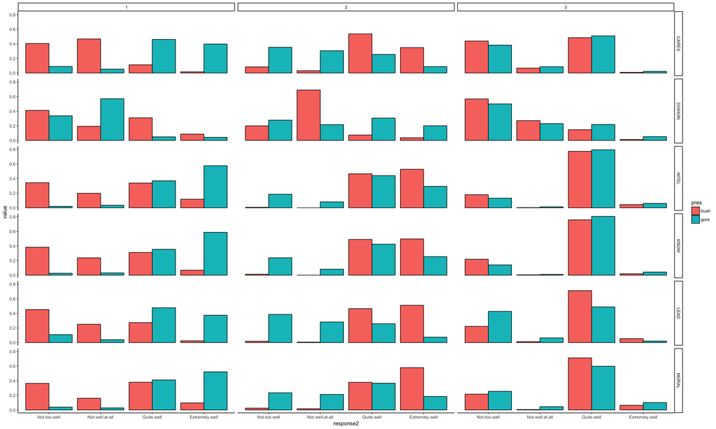

```r
as.data.frame(nes.basic$probs) %>%
  rownames_to_column("class") %>%
  gather(type, value,-class) %>%
  separate(type, c("type2", "response", "response2"), sep = "[.]", extra = "merge", fill = "right") %>%
  mutate(pres = ifelse(substr(type2,nchar(type2),nchar(type2))=="G", "gore", "bush"),
         type2 = substr(type2,1,nchar(type2)-1),
         class = as.numeric(substr(class,nchar(class)-2,nchar(class)-2)) ,
         response2 = factor(as.character(response2), levels = c("Not.too.well","Not.well.at.all","Quite.well", "Extremely.well")))->class_probs
ggplot(class_probs) +
  geom_col(aes(x = response2, y = value, fill = pres), colour = "black", position = "dodge") +
  facet_grid(type2~class) +
  theme_classic()
```

How do we interpret these groups?